# Множественная регрессия

## Мы рассмотрим

- Технику подгонки множественных регрессионных моделей
- Процесс валидации множественных регрессионных моделей

## Вы сможете

- Подобрать множественную линейную модель
- Протестировать ее статистическую значимость и валидность

## Какие факторы определяют обилие птиц во фрагментированных лесных массивах Австралии?

## Читаем данные

```r
bird <- read.csv("data/loyn.csv")
head(bird)
```

```
##   ABUND AREA YRISOL DIST LDIST GRAZE ALT
## 1   5.3  0.1   1968   39    39     2 160
## 2   2.0  0.5   1920  234   234     5  60
## 3   1.5  0.5   1900  104   311     5 140
## 4  17.1  1.0   1966   66    66     3 160
## 5  13.8  1.0   1918  246   246     5 140
## 6  14.1  1.0   1965  234   285     3 130
```

## Знакомимся с даными

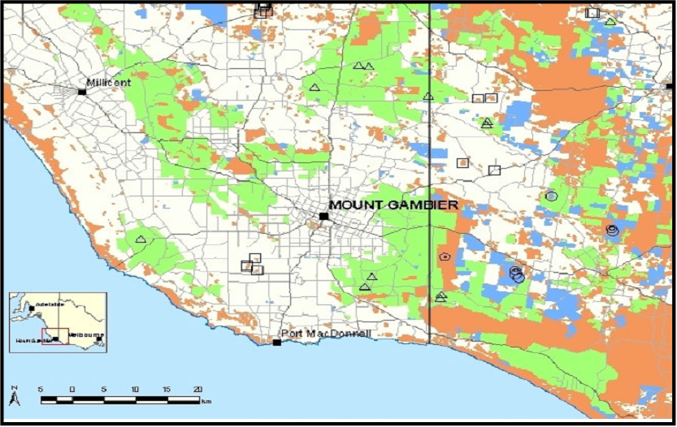

(Пример взять из книги Quinn&Keugh,2002; Оригинальная работа Loyn, 1987)

Фрагментация лесных местообитаний - одна из важнейших проблем Австралии. Вопрос: от каких факторов зависит обилие птиц во фрагментированных лесных массивах?

*Зависимая перменная*  
`ABUND` - Обилие птиц на стандартном маршруте

*Предикторы*  
`AREA` - площадь лесного массива (Га)  
`YRISOL` - год, в котором произошла изоляция лесного массива  
`DIST` - расстояние до ближайшего другого лесного массива (км)  
`LDIST` - расстояние до ближайшего более крупного массива (км)  
`GRAZE` - качественная оценка уровня выпаса скота (1 - низкий уровень, 5 - высокий урвень)  
`ALT` - высота над уровнем моря (м)

## Можно ли ответить на вопрос таким методом?

```r
cor(bird)
```

```
##          ABUND     AREA   YRISOL   DIST   LDIST  GRAZE    ALT
## ABUND   1.0000  0.25597  0.50336  0.236  0.0872 -0.683  0.386
## AREA    0.2560  1.00000 -0.00149  0.108  0.0346 -0.310  0.388
## YRISOL  0.5034 -0.00149  1.00000  0.113 -0.0833 -0.636  0.233
## DIST    0.2361  0.10834  0.11322  1.000  0.3172 -0.256 -0.110
## LDIST   0.0872  0.03458 -0.08332  0.317  1.0000 -0.028 -0.306
## GRAZE  -0.6825 -0.31040 -0.63557 -0.256 -0.0280  1.000 -0.407
## ALT     0.3858  0.38775  0.23272 -0.110 -0.3060 -0.407  1.000
```

## Взаимосвязь между переменными может находиться под контролем других переменых и их взаимодействий.

### Необходимо учесть все взаимовлияния в одном анализе

## Нам предстоит построить множественную регрессионную модель

\[y_i = \beta_0 + \beta_1x_{i1} + \beta_2x_{i2} + \beta_3x_{i3} + ... + \beta_px_{ip} + \epsilon_i\]

- \(y_i\) - значение зависимой переменной \(Y\) при значении предикторов \(X_1 = x_{i,1}\), \(X_2 = x_{i,2}\) и т.д.
- \(\beta_0\) - свободный член (intercept). Значение \(Y\) при \(X_1=X_2=X_3=....=X_p=0\)
- \(\beta_1\) - частный угловой коэффициент для зависимости \(Y\) от \(X_1\). Показывает насколько единиц изменяется \(Y\) при изменении \(X_1\) на одну единицу и при условии, что все остальные предикторы не изменяются. \(\beta_2\), \(\beta_3\), …., \(\beta_p\) - аналогично
- \(\epsilon_i\) - варьирование \(Y\), не объясняемое данной моделью.

## Геометрическая интерпретация множественной линейной модели

### Для случая с одним предиктором \(y_i = \beta_0 + \beta_1x_i + \epsilon_i\) - линия регрессии

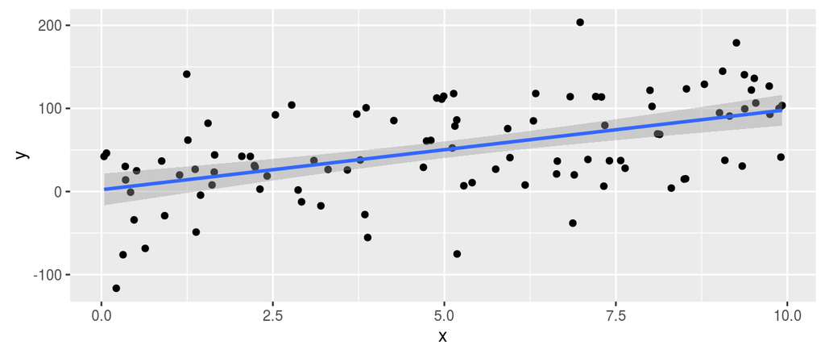

## Геометрическая интерпретация множественной линейной модели

### Для случая с двумя предикторами

\[y_i = \beta_0 + \beta_1x_{i1} + \beta_2x_{i2} + \epsilon_i\]

Плоскость в трехмерном пространстве

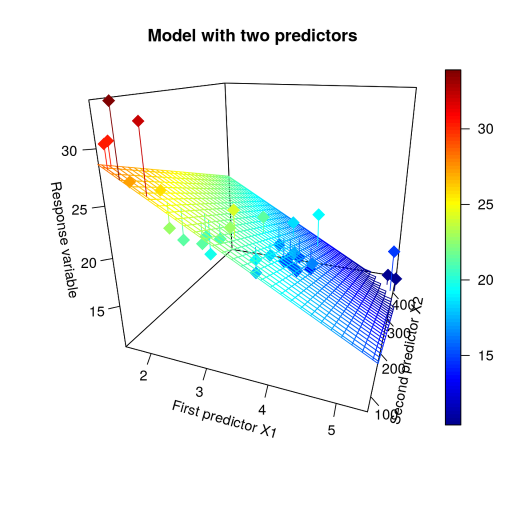

## Геометрическая интерпретация множественной линейной модели

### Для случая с большим количеством предикторов

\[y_i = \beta_0 + \beta_1x_{i1} + \beta_2x_{i2} + \beta_3x_{i3} + ... + \beta_px_{ip} + \epsilon_i\] Плоскость в n-мерном пространстве, оси которого образованы значениями предикторов

## Исследование данных (Data Exploration)

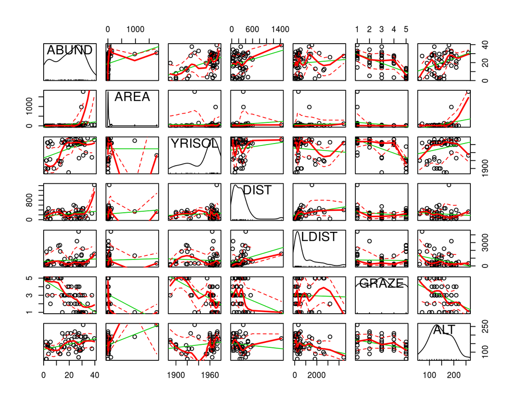

```r
library(car)
scatterplotMatrix(bird)
```

## Явные проблемы

### Есть сильные корреляции между некоторым предикторами.

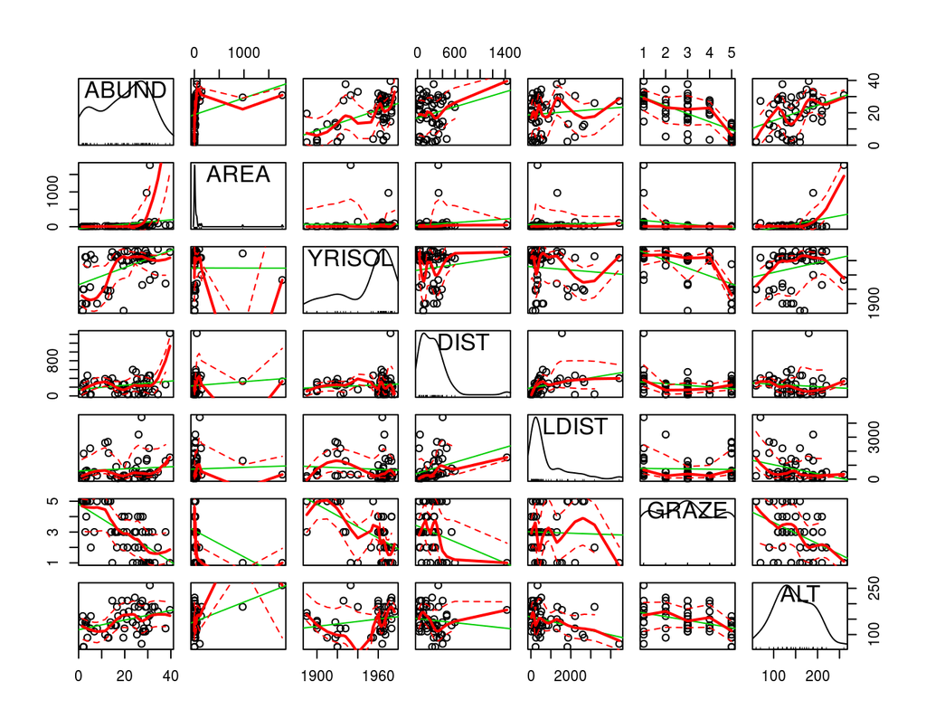

## Постоим линейную модель

### Задание. Напишите самостоятельно R код, необходимый для подбора уравнения множественной регрессии

*Hint*

```r
head(bird, 2)
```

```
##   ABUND AREA YRISOL DIST LDIST GRAZE ALT
## 1   5.3  0.1   1968   39    39     2 160
## 2   2.0  0.5   1920  234   234     5  60
```

## Решение

```r
model <- lm(ABUND ~  AREA + YRISOL + DIST + LDIST + GRAZE + ALT, data = bird)

model <- lm(ABUND ~  . , data = bird)
```

## Смотрим на полученную модель

```r
summary(model)
```

```
##
## Call:
## lm(formula = ABUND ~ ., data = bird)
##
## Residuals:
##     Min      1Q  Median      3Q     Max
## -17.664  -4.641  -0.088   4.286  20.104
##
## Coefficients:
##                Estimate  Std. Error t value Pr(>|t|)
## (Intercept) -109.696233  113.349038   -0.97   0.3379
## AREA           0.000887    0.004657    0.19   0.8498
## YRISOL         0.066928    0.056843    1.18   0.2447
## DIST           0.003811    0.005418    0.70   0.4851
## LDIST          0.001418    0.001310    1.08   0.2845
## GRAZE         -3.446640    1.106683   -3.11   0.0031 **
## ALT            0.047722    0.030888    1.54   0.1288
## ---
## Signif. codes:  0 '***' 0.001 '**' 0.01 '*' 0.05 '.' 0.1 ' ' 1
##
## Residual standard error: 7.95 on 49 degrees of freedom
## Multiple R-squared:  0.512,  Adjusted R-squared:  0.452
## F-statistic: 8.56 on 6 and 49 DF,  p-value: 0.00000224
```

## Проверка валидности модели

## Вспомним условия применимости линейных моделей

1. Линейность связи между зависимой перменной (\(Y\)) и предикторами (\(X\))
2. Независимость \(Y\) друг от друга
3. Нормальное распределение \(Y\) для каждого уровня значенй \(X\)
4. Гомогенность дисерсии \(Y\) в пределах всех уровней значений \(X\)
5. Отсутствие коллинеарности предикторов (для можественной регрессии)

## Для начала выясним нет ли среди наблюдений влияющих наблюдений

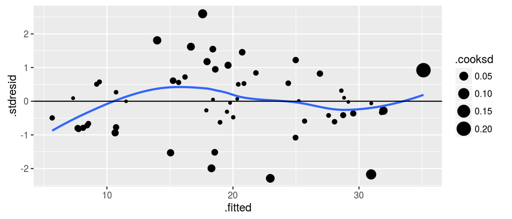

```r
library(ggplot2)
ABUND_diag <- fortify(model)
# При жестком подходе D > 4 / (N - p - 1)
# При более мягком подходе D > 1

ggplot(ABUND_diag, aes(x = .fitted, y = .stdresid)) +
  geom_point(aes(size = .cooksd)) +
  geom_smooth(se=FALSE) +
  geom_hline(aes(yintercept = 0))
```

## Проверяем распределение остатков на соответствие нормальному распределению

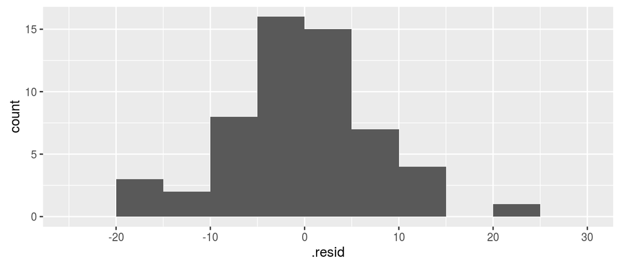

```r
ggplot(ABUND_diag, aes(x = .resid)) + geom_histogram(binwidth = 5)
```

## Проверяем распределение остатков на соответствие нормальному распределению

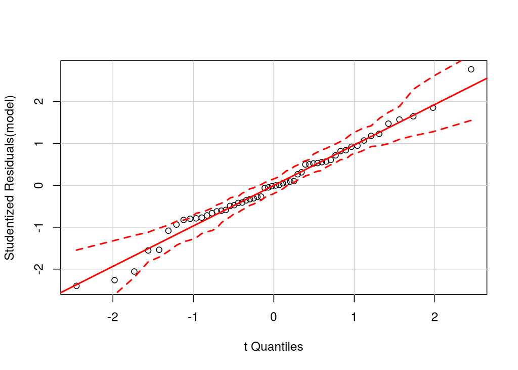

```r
library(car)
qqPlot(model)
```

## Проверяем на гетероскедастичность

[figure not shown]

```r
library(lmtest)
bptest(model)
```

```
##
##  studentized Breusch-Pagan test
##
## data:  model
## BP = 5, df = 6, p-value = 0.6
```

## Проверяем на мультиколлинеарность

*Мультиколлинеарность* - наличие линейной зависимости между независимыми переменными (факторами) регрессионной модели.

При наличии мультиколлинеарности оценки параметров получаются неточными, а значит сложно будет дать интерпретацию влияния тех или иных факторов на объясняемую переменную

Признаки мультиколлинеарности:  
+ Большие ошибки оценок параметров  
+ Большинство оценок параметров модели недостоверно, но F критерий всей модели свидетельствует о ее статистической значимости

## Фактор инфляции дисперсии (Variance inflation factor)

### Фактор инфляции дисперсии (VIF) — мера мультиколлинеарности.

```r
vif(model)
```

```
##   AREA YRISOL   DIST  LDIST  GRAZE    ALT
##   1.34   1.84   1.23   1.26   2.31   1.57
```

## Логика вычисления VIF

Мы подбираем модель, описывающую связь данного предиктора со всеми остальными предикторами.

1. Строим регрессионную модель.  
   \[x_1 = c_0 + c_2x_2 +c_2x_3 + .... + c_px_p\]
2. Находим \(R^2\) для данной модели.
3. Вычисляем фактор инфляции дисперсии. \[VIF = \frac{1}{1-R^2}\]

## Что делать, если мультиколлинеарность выявлена?

Решение № 1. Удалить из модели избыточные предикторы  
1. Последовательно удалить из модели предикторы с VIF > 5 (сначала предиктор с самым большим VIF)  
2. Вновь провести вычисление VIF 3. Если остались еще предикторы с VIF > 5, то повторить шаг 1 и 2. 4. Возможно, придется удалить и предикторы с VIF > 3  
5. Иногда полезно удалить и предикторы с VIF > 2 (Это позволит сократить набор предикторов, но не увлекайтесь!)

## Что делать если мультиколлинеарность выявлена?

Решение № 2. Заменить исходные предикторы новыми переменными, полученными с помощью метода главных компонент

## В нашей модели явной мультколлинеарности нет!

### Однако, возможно, что `GRAZE` - избыточный предиктор

## Удалим из модели избыточный предиктор

```r
model2 <- update(model, ~ . -GRAZE)
vif(model2)
```

```
##   AREA YRISOL   DIST  LDIST    ALT
##   1.25   1.10   1.16   1.24   1.43
```

## Смотрим на итоги

```r
summary(model2)
```

```
##
## Call:
## lm(formula = ABUND ~ AREA + YRISOL + DIST + LDIST + ALT, data = bird)
##
## Residuals:
##     Min      1Q  Median      3Q     Max
## -15.636  -5.211  -0.277   4.735  22.963
##
## Coefficients:
##               Estimate Std. Error t value Pr(>|t|)
## (Intercept) -344.79073   91.61744   -3.76  0.00044 ***
## AREA           0.00459    0.00488    0.94  0.35132
## YRISOL         0.17928    0.04760    3.77  0.00044 ***
## DIST           0.00772    0.00571    1.35  0.18233
## LDIST          0.00192    0.00141    1.36  0.17978
## ALT            0.07638    0.03195    2.39  0.02062 *
## ---
## Signif. codes:  0 '***' 0.001 '**' 0.01 '*' 0.05 '.' 0.1 ' ' 1
##
## Residual standard error: 8.61 on 50 degrees of freedom
## Multiple R-squared:  0.415,  Adjusted R-squared:  0.357
## F-statistic:  7.1 on 5 and 50 DF,  p-value: 0.000044
```

## Сравним две модели

```r
summary(model)$adj.r.squared
```

```
## [1] 0.452
```

```r
summary(model2)$adj.r.squared
```

```
## [1] 0.357
```

*Удаление этого предиктора, скорее, ухудшает модель!*

## Задание:

### Постройте и проанализируйте модель, описывающую связь между усилием мышц, осуществляющих выдох (`pemax`) и следующими параметрами тела

`age` - Возраст  
`sex` - Пол (0: male, 1:female)  
`height` - Рост (cm).  
`weight` - Вес (kg).  
`bmp` - Отклонения в весе от нормы (% of normal).  
`fev1` - Объем наполенных легких.  
`rv` - Остаточный объем легких.  
`frc` - Функциональная остаточная емкость легких.  
`tlc` - Общая емкость легких.

Для получения данных выполните следующий код

```r
library(ISwR)
data(cystfibr)
```

## Решение

```r
M1 <- lm(pemax ~ ., data = cystfibr)
summary(M1)
```

```
##
## Call:
## lm(formula = pemax ~ ., data = cystfibr)
##
## Residuals:
##    Min     1Q Median     3Q    Max
## -37.34 -11.53   1.08  13.39  33.41
##
## Coefficients:
##             Estimate Std. Error t value Pr(>|t|)
## (Intercept)  176.058    225.891    0.78     0.45
## age           -2.542      4.802   -0.53     0.60
## sex           -3.737     15.460   -0.24     0.81
## height        -0.446      0.903   -0.49     0.63
## weight         2.993      2.008    1.49     0.16
## bmp           -1.745      1.155   -1.51     0.15
## fev1           1.081      1.081    1.00     0.33
## rv             0.197      0.196    1.00     0.33
## frc           -0.308      0.492   -0.63     0.54
## tlc            0.189      0.500    0.38     0.71
##
## Residual standard error: 25.5 on 15 degrees of freedom
## Multiple R-squared:  0.637,  Adjusted R-squared:  0.42
## F-statistic: 2.93 on 9 and 15 DF,  p-value: 0.032
```

## Явные признаки мультиколлинеарности

```r
vif(M1)
```

```
##    age    sex height weight    bmp   fev1     rv    frc    tlc
##  21.83   2.27  13.95  47.78   7.12   5.42  10.54  17.14   2.66
```

## Удаляем избыточные предикторы

```r
M2 <- update(M1, .~.-weight)
vif(M2)
```

```
##    age    sex height    bmp   fev1     rv    frc    tlc
##   8.10   2.03   7.60   2.73   4.21  10.33  15.81   2.18
```

## Удаляем избыточные предикторы

```r
M3 <- update(M2, . ~. - frc)
vif(M3)
```

```
##    age    sex height    bmp   fev1     rv    tlc
##   7.34   1.61   7.60   1.79   2.87   2.84   1.77
```

## Удаляем избыточные предикторы

```r
M4 <- update(M3, . ~. - height)
vif(M4)
```

```
##  age  sex  bmp fev1   rv  tlc
## 1.61 1.61 1.72 2.86 2.81 1.77
```

## Смотрим на полученную модель

```r
summary(M4)
```

```
##
## Call:
## lm(formula = pemax ~ age + sex + bmp + fev1 + rv + tlc, data = cystfibr)
##
## Residuals:
##    Min     1Q Median     3Q    Max
## -50.45 -19.11   3.97  17.40  31.33
##
## Coefficients:
##             Estimate Std. Error t value Pr(>|t|)
## (Intercept)  -83.525     82.808   -1.01   0.3265
## age            5.038      1.296    3.89   0.0011 **
## sex            4.991     12.913    0.39   0.7037
## bmp           -0.403      0.564   -0.71   0.4840
## fev1           1.931      0.780    2.48   0.0234 *
## rv             0.114      0.101    1.13   0.2745
## tlc            0.465      0.405    1.15   0.2654
## ---
## Signif. codes:  0 '***' 0.001 '**' 0.01 '*' 0.05 '.' 0.1 ' ' 1
##
## Residual standard error: 25.3 on 18 degrees of freedom
## Multiple R-squared:  0.571,  Adjusted R-squared:  0.428
## F-statistic: 3.99 on 6 and 18 DF,  p-value: 0.0103
```

## Диагностика модели

```r
plot(M4)
```

[output not shown]

## Какой из предиктов оказывает наиболее сильное влияние?

### Для ответа на этот вопрос надо "уравнять" шкалы, всех предикторов, то есть стандартизировать их.

## Задание.

### Нпишите R-код, который позволяет стандартизировать шкалу предиктора. Стандаризируйе, например, вектор `fev1`

## Решение

```r
# 1 способ:

(cystfibr$fev1 - mean(cystfibr$fev1))/sd(cystfibr$fev1)

# 2 способ: with, чтобы меньше писать

with(cystfibr,
  (fev1 - mean(fev1))/sd(fev1)
)

# 3 способ:

scale(cystfibr$fev1)
```

```
##  [1] -0.2429 -1.4039 -1.1360  0.5609  1.5432  0.8288 -0.6002 -1.4932
##  [9] -0.9574 -1.0467  0.3822 -0.7788  0.9181  0.9181 -0.3322 -0.5108
## [17]  1.2753 -0.5108  0.2929 -1.2253  0.2036 -0.0643  1.9898 -0.1536
## [25]  1.5432
```

## Можно использовать функцию `scale()`

```r
M4_scaled <- lm(pemax ~ scale(age) + sex + scale(bmp) + scale(fev1) + scale(rv) +
    scale(tlc), data = cystfibr)
```

## Какой факторов оказывает наиболее сильное влияние на усилие дыхательных мышц?

```r
summary(M4_scaled)
```

```
##
## Call:
## lm(formula = pemax ~ scale(age) + sex + scale(bmp) + scale(fev1) +
##     scale(rv) + scale(tlc), data = cystfibr)
##
## Residuals:
##    Min     1Q Median     3Q    Max
## -50.45 -19.11   3.97  17.40  31.33
##
## Coefficients:
##             Estimate Std. Error t value Pr(>|t|)
## (Intercept)   106.92       7.61   14.06  3.8e-11 ***
## scale(age)     25.49       6.55    3.89   0.0011 **
## sex             4.99      12.91    0.39   0.7037
## scale(bmp)     -4.84       6.77   -0.71   0.4840
## scale(fev1)    21.63       8.73    2.48   0.0234 *
## scale(rv)       9.76       8.66    1.13   0.2745
## scale(tlc)      7.89       6.87    1.15   0.2654
## ---
## Signif. codes:  0 '***' 0.001 '**' 0.01 '*' 0.05 '.' 0.1 ' ' 1
##
## Residual standard error: 25.3 on 18 degrees of freedom
## Multiple R-squared:  0.571,  Adjusted R-squared:  0.428
## F-statistic: 3.99 on 6 and 18 DF,  p-value: 0.0103
```

## Задание

### Оцените валидность финальной модели с помощью тестов на гетероскедастичность, автокоррелированность данных и наличие мультиколлинеарности

## Оцениваем валидность финальной модели

```r
durbinWatsonTest(M4_scaled)
```

```
##  lag Autocorrelation D-W Statistic p-value
##    1           -0.15          2.21   0.772
##  Alternative hypothesis: rho != 0
```

```r
bptest(M4_scaled)
```

```
##
##  studentized Breusch-Pagan test
##
## data:  M4_scaled
## BP = 7, df = 6, p-value = 0.3
```

```r
vif(M4_scaled)
```

```
##  scale(age)         sex  scale(bmp) scale(fev1)   scale(rv)
##        1.61        1.61        1.72        2.86        2.81
##  scale(tlc)
##        1.77
```

## Взаимодействия предикторов

## Вернемся к данным по обилию птиц и построим модель для двух предикторов

```r
model3 <- lm(ABUND ~ YRISOL + GRAZE, data = bird)
summary(model3)
```

```
##
## Call:
## lm(formula = ABUND ~ YRISOL + GRAZE, data = bird)
##
## Residuals:
##     Min      1Q  Median      3Q     Max
## -19.469  -4.755   0.317   4.473  19.330
##
## Coefficients:
##             Estimate Std. Error t value Pr(>|t|)
## (Intercept) -62.7491   107.3923   -0.58     0.56
## YRISOL        0.0490     0.0542    0.90     0.37
## GRAZE        -4.4398     0.9418   -4.71 0.000018 ***
## ---
## Signif. codes:  0 '***' 0.001 '**' 0.01 '*' 0.05 '.' 0.1 ' ' 1
##
## Residual standard error: 7.93 on 53 degrees of freedom
## Multiple R-squared:  0.474,  Adjusted R-squared:  0.454
## F-statistic: 23.9 on 2 and 53 DF,  p-value: 0.0000000405
```

```r
model4 <- lm(ABUND ~ YRISOL * GRAZE, data = bird)
summary(model4)
```

```
##
## Call:
## lm(formula = ABUND ~ YRISOL * GRAZE, data = bird)
##
## Residuals:
##     Min      1Q  Median      3Q     Max
## -18.564  -4.300   0.961   4.050  15.378
##
## Coefficients:
##               Estimate Std. Error t value Pr(>|t|)
## (Intercept)   625.8955   304.2770    2.06    0.045 *
## YRISOL         -0.3028     0.1552   -1.95    0.056 .
## GRAZE        -177.1773    71.8370   -2.47    0.017 *
## YRISOL:GRAZE    0.0885     0.0368    2.40    0.020 *
## ---
## Signif. codes:  0 '***' 0.001 '**' 0.01 '*' 0.05 '.' 0.1 ' ' 1
##
## Residual standard error: 7.6 on 52 degrees of freedom
## Multiple R-squared:  0.527,  Adjusted R-squared:  0.499
## F-statistic: 19.3 on 3 and 52 DF,  p-value: 0.0000000155
```

## Как трактовать взаимодействия?

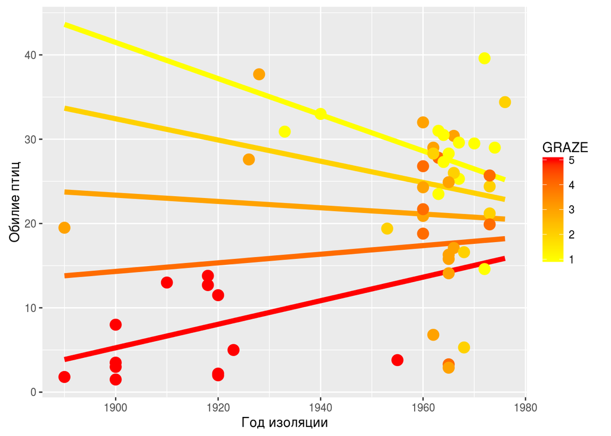

НО! Не всегда все так просто трактуется…  
Часто трактовка взаимодействий затруднительна, особенно если предкторов много.

## Include or Don't include? That is the question…

### Вопрос о включени в модель взаимоодействия предикторов совсем непростой

*Существует несколько подходов*  
1. Не включать взаимодействия в модель. Но если при валидации модели в остатках появляется явный паттерн, то это может быть следствием наличия взаимодействия предикторов.  
2. Оснвываясь на априорных знаниях свойств объектов включить только те взаимоотношения, которые имеют биологический смысл.  
3. В процессе анализа данных выявить важные взаимодействия и включить их в анализ.  
4. Среди большого количества предикторов выбрать наиболее важные переменные (те, ради которых была затеяна работа). Включить в модель взаимоотношения этих предикторов с другими, менее важными, перменными.  
5. Включать в анализ только сами перменные (main terms) и взаимодействия первого уровня (two-way interaction terms).  
6. Включать в анализ и обсуждать все взаимодействия (это имеет смысл только при малом количестве предикторов).

## Summary

- При построении множественной регрессии важно, помимо проверки прочих условий применимости, проверить модель на наличие мультиколлинеарности
- Если модель построена на основе стандартизированнх значений предикторов, то можно сравнивать влияние этих прдикторов.
- Построенную модель можно улчшать.
- В модель можно (а иногда и необходимо) включать взаимодействия предикторов.

## Что почитать

- Кабаков Р.И. R в действии. Анализ и визуализация данных на языке R. М.: ДМК Пресс, 2014.
- Quinn G.P., Keough M.J. (2002) Experimental design and data analysis for biologists, pp. 92-98, 111-130
- Diez D. M., Barr C. D., Cetinkaya-Rundel M. (2014) Open Intro to Statistics., pp. 354-367.
- Logan M. (2010) Biostatistical Design and Analysis Using R. A Practical Guide, pp. 170-173, 208-211
- Zuur, A.F. et al. 2009. Mixed effects models and extensions in ecology with R. - Statistics for biology and health. Springer, New York, NY. pp. 538-552.